# Build a Degree Day Decision Support Tool in R

Part 1. Degree Days

[figure not shown]

May 3, 2024  
https://ucanr-igis.github.io/degday-shiny-s24/

[figure not shown]

# Start Recording

[figure not shown]

# About Me…

[figure not shown]

# IGIS Team

[figure not shown]

# About You

Type of Organization

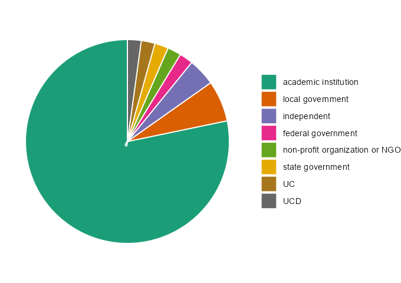

Email domain

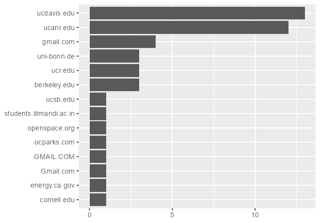

Location

[interactive chart not shown]

Familiarity with degree days

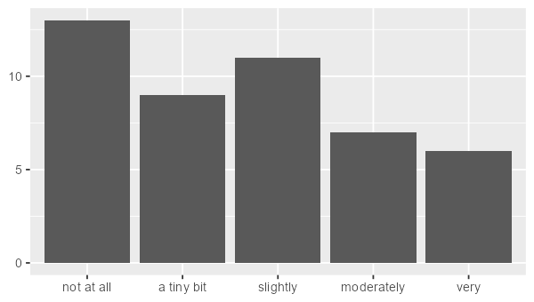

Familiarity with R

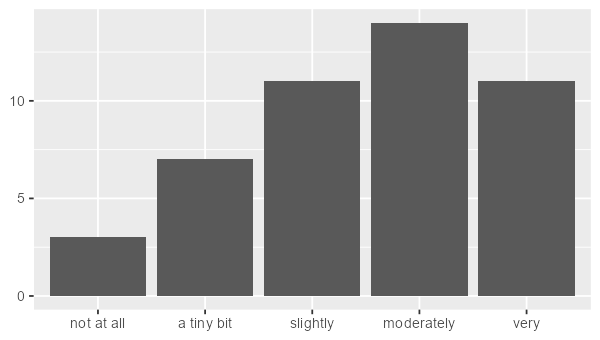

# Related Work

[figure not shown]

# Workshop Goals

## Primary focus

*Programming techniques for working with weather data and degree day models in R*

## What we will cover

### Degree Days

- about degree days and degree days models
- how to compute degree days in R
- using degree day models to make predictions
- visualizing predictions

### Weather Data

- what makes good weather data
- weather data APIs for:
- recent past
- short term forecast
- historical averages
- seasonal projections
- modeled climate futures
- calling weather APIs
- R packages with API wrappers
- writing your own code to query APIs
- wrangling weather data

### Creating a Web App Decision Support Tool

- Shiny web apps
- reactive programming
- deploying Shiny apps

## What we will not cover

- scientific and statistical assumptions and limitations of
- degree day models
- weather data
- weather models
- techniques & strategies for downloading and (re)publishing weather data
- other approaches to querying weather data services
- ArcGIS services
- gdal
- more complicated analyses
- best practices using modeled climate futures
- transforming model predictions into digestible and actionable information
- daisy-chaining models
- intermediate and advanced features of Shiny

# Take Home Messages

Degree day models are widely used to predict the development / phenology of plants and insects

They are widely used in:

- research
- planning
- developing decision support tools for crop management

Implementing degree days requires:

- getting daily or hourly temperature data
- data wrangling

R is well-equipped to wrangle data, compute degree days, and make predictions

APIs have simplified importing weather data, but its still tricky

Shiny greatly simplifies developing and publishing degree days models as lightweight web apps

# Workshop Materials

# Degree Days

[figure not shown]

# `dplyr`

[figure not shown]

## Top `dplyr` Functions

| subset rows | filter(), slice() |
| --- | --- |
| order rows | arrange() |
| pick column(s) | select(), pull() |
| add new columns | mutate() |

# Piping syntax

Piping allows the **result** of one function to be passed as the **first argument** of the next function.

Pipe operators:

- ‘native’ pipe: |>
- classic (`magrittr`) pipe: %>%

This allows a series of functions to be **written like a sentence**.

zoo(moo(boo(foo(99)),n=4))

[figure not shown]

# `degday`

## Overview

- available on CRAN
- contains functions for all the equations from Zalom et. al. ([1983](https://catalog.hathitrust.org/Record/008707238)) and McMaster and Wilhelm ([1997](https://digitalcommons.unl.edu/cgi/viewcontent.cgi?article=1086&context=usdaarsfacpub))
- results have been validated with reference data from Zalom et. al. and the [UC IPM](https://ipm.ucanr.edu/WEATHER/index.html) website (see also [Degree Days Validation Challenge](https://ucanr-igis.github.io/degree-day-challenge/))
- the package does *not* include:
- vertical and intermediate cutoff methods
- degree hours
- models for using degree days

[figure not shown]

https://ucanr-igis.github.io/degday/

## Functions

`dd_simp_avg()`  
`dd_sng_sine()`  
`dd_dbl_sine()`  
`dd_sng_tri()`  
`dd_dbl_tri()`

**Usage Notes**

- The equations require a vector of minimum and maximum temperature values.
- they presume these are daily min and max values (but do not check)
- they return a vector of degree days of the same length
- If your goal is to compute accumulated degree days starting from a specific biofix date, then:
1. Filter the weather data by date
2. Use `mutate()` with one of the above functions to add a column for daily degree days
3. Create an additional column for the accumulated degree days (e.g, using `mutate()` and `cumsum()`)
- Make sure the upper/lower thresholds have the **same units** as the weather data.

## Example:

Load some sample data:

```r
library(degday)

espartoa_tbl <- system.file("extdata/espartoa-weather-2020.csv", package = "degday") |>
  read.csv() |>
  mutate(date = as.Date(date))

head(espartoa_tbl)
```

```
##     station       date tmin tmax
## 1 Esparto.A 2020-01-01   38   55
## 2 Esparto.A 2020-01-02   36   67
## 3 Esparto.A 2020-01-03   33   59
## 4 Esparto.A 2020-01-04   37   59
## 5 Esparto.A 2020-01-05   38   63
## 6 Esparto.A 2020-01-06   36   58
```

Compute daily degree days using the single sine method, and save it as a new column:

```r
espartoa_tbl |>
  mutate(degdays = dd_sng_sine(daily_min = tmin, daily_max = tmax,
                                thresh_low = 55, thresh_up = 93.9)) |>
  mutate(acc_degdays = cumsum(degdays)) |>
  head()
```

```
##  - using single sine method
```

```
##     station       date tmin tmax degdays acc_degdays
## 1 Esparto.A 2020-01-01   38   55    0.00        0.00
## 2 Esparto.A 2020-01-02   36   67    3.31        3.31
## 3 Esparto.A 2020-01-03   33   59    0.68        3.99
## 4 Esparto.A 2020-01-04   37   59    0.74        4.73
## 5 Esparto.A 2020-01-05   38   63    1.99        6.72
## 6 Esparto.A 2020-01-06   36   58    0.48        7.20
```

## Double-Sine and Double-Triangle Methods

The double-sine and double-triangle methods require adding tomorrow’s minimum temperature as an additional column:

```r
espartoa_plus2mrw_tbl <- espartoa_tbl |>
  mutate(tomorrow_tmin = lead(tmin, n = 1))

head(espartoa_plus2mrw_tbl)
```

```
##     station       date tmin tmax tomorrow_tmin
## 1 Esparto.A 2020-01-01   38   55            36
## 2 Esparto.A 2020-01-02   36   67            33
## 3 Esparto.A 2020-01-03   33   59            37
## 4 Esparto.A 2020-01-04   37   59            38
## 5 Esparto.A 2020-01-05   38   63            36
## 6 Esparto.A 2020-01-06   36   58            30
```

```r
espartoa_plus2mrw_tbl |>
  mutate(dbl_tri = dd_dbl_tri(daily_min = tmin, daily_max = tmax,
                              nextday_min = tomorrow_tmin,
                              thresh_low = 55, thresh_up = 93.9)) |>
  head()
```

```
##  - using double triangle method
```

```
##     station       date tmin tmax tomorrow_tmin dbl_tri
## 1 Esparto.A 2020-01-01   38   55            36    0.00
## 2 Esparto.A 2020-01-02   36   67            33    2.22
## 3 Esparto.A 2020-01-03   33   59            37    0.34
## 4 Esparto.A 2020-01-04   37   59            38    0.37
## 5 Esparto.A 2020-01-05   38   63            36    1.23
## 6 Esparto.A 2020-01-06   36   58            30    0.18
```

# `ggplot`

```r
library(ggplot2)
library(palmerpenguins)

ggplot(penguins, aes(x = flipper_length_mm, y = bill_length_mm, color = species)) +
  geom_point() +
  ggtitle("Bill Length vs Flipper Length for 3 Species of Penguins")
```

[figure not shown]

## Anatomy of a ggplot expression

[figure not shown]

# R Notebooks

R Notebooks are written in “R Markdown”, which combines text and R code.

[figure not shown]

# Notebook #1: Compute Degree Days

## Posit Cloud users

https://posit.cloud/content/8147278

Click ‘Save a permanent copy’

Done!

## RStudio Desktop Power Users

### 1. Download RStudio project

Download a RStudio project with all the exercises and data:

#### Option 1

```r
## Download and open on desktop
usethis::use_course("https://bit.ly/degday-weather-wrkshp-rproj-s24")

## Download to a specific location
## usethis::use_course("https://bit.ly/degday-weather-wrkshp-rproj-s24", destdir = "c:/workshops")
```

#### Option 2

1. download zip file: https://bit.ly/degday-weather-wrkshp-rproj-s24
2. unzip
3. open `degday-shiny-s24.Rproj`

### 2. Install required packages

`/scripts/install_packages.R`